# Havard data test

```r
library(dplyr)
library(ggplot2)
library(haven)
library(zoo)
```

# Q1

Import data

```r
character_test <- read_dta("C:/Users/haoch/Desktop/RA test/Havard/character_test.dta")
test_sample <- read_dta("C:/Users/haoch/Desktop/RA test/Havard/test_sample.dta")
```

# Q2

9999998 is NA value for ces_origbal replace 9999998 with NA

```r
test_sample$ces_origbal[which(test_sample$ces_origbal == 9999998)] =NA
```

# Q3

There is only one value for variable mbadelinquencystatus: C However, from Q4 I find there might be 3 , 9, 6 , _ , B , F values for mbastatus. Because I don’t know the exact definition of this variable, I am not sure about this answer

```r
table(test_sample$mbadelinquencystatus)
```

```
##
##    C
## 9412
```

# Q4

Due to the time limit, I don’t know exact definition of this variable. I think the the fifth from last character represents status possibilities 5 months ago. So I calculate the proportion of the fifth from last character which is not ‘C’. The proportion is 0.002974926

```r
table(test_sample$mbastatushist12mos)
```

```
##
## 3CCCCCCCCCCC C___________ C_CCCCCCCCCC C3CCCC3CC3CC C3CCCCCCCCCC CC__________
##            2            1            2            1            2            1
## CC_CCCCCCCCC CC3CCCCCCCCC CCC_________ CCC333CC3636 CCC3CCCCCCCC CCCC________
##            2            2            1            1            1            2
## CCCC_CCCCCCC CCCC3CCCCCCC CCCC63C63CCC CCCCC_______ CCCCC_CCCCCC CCCCC3366633
##            1            3            1            3            1            1
## CCCCC33C33CC CCCCC33CCCCC CCCCC3C3CCCC CCCCC3CCC3C3 CCCCC3CCCCCC CCCCC63CCCC3
##            1            1            2            1            3            1
## CCCCC9999966 CCCCCC______ CCCCCC336663 CCCCCC3CCC3C CCCCCC3CCCC3 CCCCCC3CCCCC
##            1            4            1            1            1            1
## CCCCCC3FFFF9 CCCCCC999996 CCCCCCBBCCCC CCCCCCC_____ CCCCCCC3CCCC CCCCCCCC____
##            1            1            1            3            3            3
## CCCCCCCC_CCC CCCCCCCC3366 CCCCCCCC33CC CCCCCCCC3CCC CCCCCCCC63C3 CCCCCCCCC___
##            1            1            2            5            1            6
## CCCCCCCCC_CC CCCCCCCCC333 CCCCCCCCC33C CCCCCCCCC3C3 CCCCCCCCC3CC CCCCCCCCC3FF
##            2            1            1            1            5            1
## CCCCCCCCC63C CCCCCCCCC663 CCCCCCCCCBBB CCCCCCCCCC__ CCCCCCCCCC_C CCCCCCCCCC33
##            1            1            1            2            3            2
## CCCCCCCCCC3C CCCCCCCCCC63 CCCCCCCCCCC_ CCCCCCCCCCC3 CCCCCCCCCCC6 CCCCCCCCCCCB
##            6            1            7            9            5            2
## CCCCCCCCCCCC CCCCCCCCFF96 CCFFFFF963CC
##         9285            1            1
```

```r
#define a variable for mbastatus 5 months ago
test_sample$mbastatushist5mos=substr(test_sample$mbastatushist12mos,8,8)
table(test_sample$mbastatushist5mos)
```

```
##
##    _    3    6    9    B    C    F
##   15    6    2    3    1 9384    1
```

```r
1-9384/nrow(test_sample)
```

```
## [1] 0.002974926
```

# Q5

I choose all_curbal value to calculate the aggregate balance for individuals. ‘all_curbal’ represents all current balance (not sure)

```r
graph=test_sample%>%group_by(month)%>%summarise(agg_bal=sum(all_curbal))
#transform month value into Year-month format
graph$Date=as.yearmon(graph$month, '%Y%m')
```

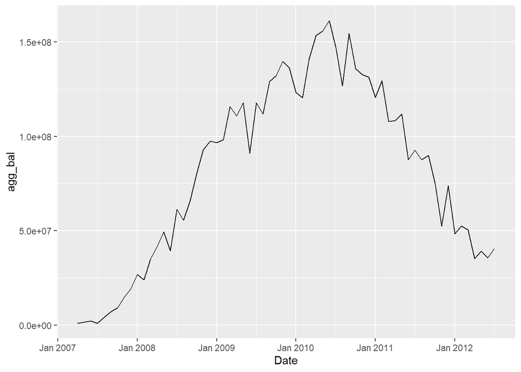

```r
#graph
ggplot(graph, aes(Date, agg_bal)) + geom_line()
```

# Q6

The aggregate balance keeps increasing from 2007 to 2010 and reaches the peak in 2010. Then, it keeps decreasing untill 2012. The changes in these 5 years is a boom-bust cycle.

# Q7

Merge

```r
demo=left_join(test_sample,character_test,by="loanid")
```

# Q8

all_curbal represents current balance

```r
reg1=lm(log(all_curbal)~log(zhvi_current),data =demo)
summary(reg1)
```

```
##
## Call:
## lm(formula = log(all_curbal) ~ log(zhvi_current), data = demo)
##
## Residuals:
##      Min       1Q   Median       3Q      Max
## -2.06284 -0.37759 -0.03651  0.34512  2.94993
##
## Coefficients:
##                   Estimate Std. Error t value Pr(>|t|)
## (Intercept)       5.012476   0.120813   41.49   <2e-16 ***
## log(zhvi_current) 0.634928   0.009603   66.12   <2e-16 ***
## ---
## Signif. codes:  0 '***' 0.001 '**' 0.01 '*' 0.05 '.' 0.1 ' ' 1
##
## Residual standard error: 0.5731 on 8959 degrees of freedom
##   (451 observations deleted due to missingness)
## Multiple R-squared:  0.3279, Adjusted R-squared:  0.3279
## F-statistic:  4372 on 1 and 8959 DF,  p-value: < 2.2e-16
```

# Q9

I use month variable to capture month fixed effect

```r
reg2=lm(log(all_curbal)~log(zhvi_current)+as.factor(month),data =demo)
summary(reg2)
```

```
##
## Call:
## lm(formula = log(all_curbal) ~ log(zhvi_current) + as.factor(month),
##     data = demo)
##
## Residuals:
##      Min       1Q   Median       3Q      Max
## -2.06292 -0.36631 -0.03655  0.33966  2.98077
##
## Coefficients:
##                         Estimate Std. Error t value Pr(>|t|)
## (Intercept)             4.654100   0.422304  11.021   <2e-16 ***
## log(zhvi_current)       0.647580   0.009628  67.260   <2e-16 ***
## as.factor(month)200706  0.331574   0.519704   0.638    0.523
## as.factor(month)200707 -0.571881   0.519707  -1.100    0.271
## as.factor(month)200708 -0.263841   0.437644  -0.603    0.547
## as.factor(month)200709 -0.273324   0.424354  -0.644    0.520
## as.factor(month)200710 -0.083772   0.421331  -0.199    0.842
## as.factor(month)200711 -0.078989   0.415385  -0.190    0.849
## as.factor(month)200712 -0.040201   0.413325  -0.097    0.923
## as.factor(month)200801  0.022823   0.410401   0.056    0.956
## as.factor(month)200802  0.031179   0.410733   0.076    0.939
## as.factor(month)200803  0.015923   0.408835   0.039    0.969
## as.factor(month)200804  0.015528   0.407597   0.038    0.970
## as.factor(month)200805  0.067363   0.407291   0.165    0.869
## as.factor(month)200806  0.012465   0.407307   0.031    0.976
## as.factor(month)200807  0.100913   0.406632   0.248    0.804
## as.factor(month)200808  0.075801   0.406348   0.187    0.852
## as.factor(month)200809  0.121689   0.406235   0.300    0.765
## as.factor(month)200810  0.138360   0.405726   0.341    0.733
## as.factor(month)200811  0.130338   0.405154   0.322    0.748
## as.factor(month)200812  0.188902   0.405191   0.466    0.641
## as.factor(month)200901  0.125941   0.404860   0.311    0.756
## as.factor(month)200902  0.234665   0.404988   0.579    0.562
## as.factor(month)200903  0.193656   0.404725   0.478    0.632
## as.factor(month)200904  0.169251   0.404790   0.418    0.676
## as.factor(month)200905  0.168576   0.404450   0.417    0.677
## as.factor(month)200906  0.202004   0.405284   0.498    0.618
## as.factor(month)200907  0.139623   0.404511   0.345    0.730
## as.factor(month)200908  0.184385   0.404734   0.456    0.649
```

[output cut: 27 more lines]

```
## as.factor(month)201112  0.248807   0.405917   0.613    0.540
## as.factor(month)201201  0.259332   0.406869   0.637    0.524
## as.factor(month)201202  0.313177   0.407890   0.768    0.443
## as.factor(month)201203  0.263508   0.407331   0.647    0.518
## as.factor(month)201204  0.264093   0.409383   0.645    0.519
## as.factor(month)201205  0.278689   0.408346   0.682    0.495
## as.factor(month)201206  0.342222   0.410292   0.834    0.404
## as.factor(month)201207  0.378158   0.409734   0.923    0.356
## ---
## Signif. codes:  0 '***' 0.001 '**' 0.01 '*' 0.05 '.' 0.1 ' ' 1
##
## Residual standard error: 0.5693 on 8897 degrees of freedom
##   (451 observations deleted due to missingness)
## Multiple R-squared:  0.3413, Adjusted R-squared:  0.3366
## F-statistic: 73.18 on 63 and 8897 DF,  p-value: < 2.2e-16
```

# Q10

I use efx_zipcode variable to capture zipocde fixed effect

```r
reg3=lm(log(all_curbal)~log(zhvi_current)+as.factor(month)+as.factor(efx_zipcode),data =demo)
summary(reg3)
```

```
##
## Call:
## lm(formula = log(all_curbal) ~ log(zhvi_current) + as.factor(month) +
##     as.factor(efx_zipcode), data = demo)
##
## Residuals:
##      Min       1Q   Median       3Q      Max
## -1.86915 -0.06231  0.00000  0.05738  2.30804
##
## Coefficients:
##                               Estimate Std. Error t value Pr(>|t|)
## (Intercept)                  7.4936784  0.3728660  20.098  < 2e-16 ***
## log(zhvi_current)            0.3517370  0.0194417  18.092  < 2e-16 ***
## as.factor(month)200706       0.2650061  0.3179191   0.834 0.404555
## as.factor(month)200707      -0.4738473  0.3081461  -1.538 0.124159
## as.factor(month)200708      -0.2481115  0.2706286  -0.917 0.359281
## as.factor(month)200709      -0.1949215  0.2636449  -0.739 0.459730
## as.factor(month)200710       0.0114674  0.2597824   0.044 0.964792
## as.factor(month)200711      -0.0410948  0.2569048  -0.160 0.872916
## as.factor(month)200712      -0.0757392  0.2561735  -0.296 0.767502
## as.factor(month)200801      -0.0805034  0.2520514  -0.319 0.749438
## as.factor(month)200802      -0.0380826  0.2536299  -0.150 0.880650
## as.factor(month)200803      -0.0146765  0.2526308  -0.058 0.953675
## as.factor(month)200804      -0.0039076  0.2517519  -0.016 0.987616
## as.factor(month)200805       0.0160900  0.2515117   0.064 0.948994
## as.factor(month)200806      -0.0682815  0.2515226  -0.271 0.786036
## as.factor(month)200807      -0.0279540  0.2509559  -0.111 0.911310
## as.factor(month)200808       0.0079600  0.2507635   0.032 0.974678
## as.factor(month)200809      -0.0390493  0.2507356  -0.156 0.876243
## as.factor(month)200810       0.0400600  0.2503671   0.160 0.872882
## as.factor(month)200811       0.0481917  0.2499447   0.193 0.847114
## as.factor(month)200812       0.0387118  0.2500454   0.155 0.876968
## as.factor(month)200901      -0.0048066  0.2498332  -0.019 0.984651
## as.factor(month)200902       0.0477772  0.2499548   0.191 0.848419
## as.factor(month)200903       0.0441937  0.2497683   0.177 0.859562
## as.factor(month)200904       0.0108122  0.2497578   0.043 0.965471
## as.factor(month)200905       0.0243219  0.2494211   0.098 0.922321
## as.factor(month)200906       0.0313366  0.2501654   0.125 0.900318
## as.factor(month)200907       0.0083030  0.2496095   0.033 0.973465
## as.factor(month)200908       0.0235704  0.2497922   0.094 0.924826
```

[output cut: 2025 more lines]

```
## as.factor(efx_zipcode)98837  0.8427314  0.2277504   3.700 0.000217 ***
## as.factor(efx_zipcode)98930  0.1116528  0.2277795   0.490 0.624022
## as.factor(efx_zipcode)98944  0.5835738  0.2788792   2.093 0.036424 *
## as.factor(efx_zipcode)99205  0.2646515  0.2797680   0.946 0.344198
## as.factor(efx_zipcode)99216  0.2912314  0.3598596   0.809 0.418375
## as.factor(efx_zipcode)99223  0.5836486  0.3601604   1.621 0.105165
## as.factor(efx_zipcode)99504  1.4040763  0.2087943   6.725 1.90e-11 ***
## as.factor(efx_zipcode)99516  1.9690854  0.3611439   5.452 5.14e-08 ***
## ---
## Signif. codes:  0 '***' 0.001 '**' 0.01 '*' 0.05 '.' 0.1 ' ' 1
##
## Residual standard error: 0.3209 on 6899 degrees of freedom
##   (451 observations deleted due to missingness)
## Multiple R-squared:  0.8377, Adjusted R-squared:  0.7892
## F-statistic: 17.28 on 2061 and 6899 DF,  p-value: < 2.2e-16
```

# Q11

For regression 1, log (Zillow house prices) has significant and positive influence on log (current balance), which means increasing Zillow house prices by 1% will increase current balance by 0.63%. Intuitively, house is a necessary good for most people; and when the house price increases, people need to borrow more to buy or rent a house.

For regression 2, log (Zillow house prices) has significant and positive influence on log (current balance) controlling month fixed effect, which means increasing Zillow house prices by 1% will increase current balance by 0.65% after controlling month fixed effect. From Q5 we find balance also changes with the time. So we control time fixed effect in this regression.

For regression 3, log (Zillow house prices) has significant and positive influence on log (current balance) controlling both month and zip code fixed effects, which means increasing Zillow house prices by 1% will increase current balance by 0.35% after controlling both month and zip code fixed effects. Besides time fixed effect, the location could also influence the balance (e.g. people in big cities might have high balance). So we add zip code fixed effect in this regression.